# SmartPixels Tier-2

## From inner-pixel hits to Level-1 trigger capability

**digiRefit → refit-quality BDT → coherent downstream reco → jet tagging & vertexing**

Nick Manganelli — SmartPixels internal talk — July 2026

Interactive deck: the refit-replay visualizer and the MVA explorer are live HTML — links on their slides.

## The thesis

> **Better inner-pixel information → better L1 tracks → new trigger capability.**

CMS Phase-2 L1 tracks are built from the **outer tracker only** (r > 25 cm). SmartPixels asks: what if the trigger could also see the **inner pixel barrel** (r < 16 cm), where impact parameters and vertices actually live?

**The R&D-payoff framing** — each layer of this work stands on its own:

| layer | Phase-2-baseline value *even if SmartPixels is never adopted* |
| --- | --- |
| track refit machinery | pixel-augmented L1 tracking studies, truth-linked nano tooling |
| refit-quality BDT | track-quality MVA methodology, bit-exact FPGA (conifer) path |
| tagger / vertex R&D | L1 jet-flavor + vertexing improvements on the baseline track trigger |

### Cheat sheet (CMS-isms used in this talk)

| term | meaning |
| --- | --- |
| **L1 / L1T** | Level-1 trigger: 40 MHz custom-hardware decision layer (FPGA, µs latency) |
| **OT / IT** | outer tracker (r ≈ 25–110 cm) / inner tracker = pixels (TBPX barrel, r ≈ 3–16 cm) |
| **L1TT / TTTrack** | Phase-2 L1 Track Trigger; its track object (rinv, φ0, tanλ, z0, d0) |
| **stub** | correlated hit pair in an OT pT-module — the L1 tracking primitive |
| **TP** | TrackingParticle: the truth particle a reco track is matched to |
| **GTT** | Global Track Trigger: track-only trigger objects (primary vertex, sums) |
| **PF / PUPPI** | Particle Flow (link tracks+calo into candidates) / per-particle pileup weighting |
| **SC4 / SC8** | seeded-cone L1 jets, R = 0.4 / 0.8 |
| **KF** | Kalman filter: sequential fit update, one measurement at a time |

## Where Tier-2 came from: the tier model

Separate **what exists** from **what is being rehearsed**:

| tier | status | what it is |
| --- | --- | --- |
| **Tier 3 — `refit`** | reserved | the true system: consumes a real SmartTracklet collection from a future L1 SmartPixels track finder (mode name + config plumbed, raises if selected) |
| **Tier 2 — `digiRefit`** | **implemented** | OT L1Tracks projected into TBPX; hit candidates are the **real persisted pixel digis** — occupancy, combinatorics and fakes come for free; only the cluster **angle** information is synthesized |
| Tier 1 — TP-projection toys | footnote | degenerate path of the same producer |

Tier-2 truth is *per-digi* via `PixelDigiSimLink`: a same-TP digi gets angles from the track's own parent, an other-TP digi from **its** parent, a no-link digi from a noise distribution — **correct fake phenomenology by construction**.

## NanoAOD capability, today

One flat, columnar file per configuration carries the **whole loop** (production → training → eval):

- **Extended SmartPix nano flavors** — tracks + PF + jets + gen in one file (`L1PFTrkNanoSmartPix+withGen`)
- **Per-variant track tables** — refit output for each layer config, row-aligned with the reference `L1TTrack`
- **Refit sidecar** — per-hit link tables: χ² increments, pulls, window multiplicity, hit-truth class
- **Truth by index** — matched-TP *full* parameters on every track (`tp_d0`, `tp_z0`, `tp_phi`, production vertex) → resolution-vs-truth offline, no re-matching
- **Jet side** — SC4 **and** SC8 seeded-cone jets, PF-candidate link tables (−1/−2 sentinel convention), embedded OT stubs

### Two coherent nano products (both proven in production)

**Fat coherent nano** — *one* config, *fully coherent downstream*: refit tracks → **re-run Layer-1 correlator + vertex in-job** → PF → PUPPI → SC4/SC8 jets all computed **from the refit tracks** (`nano_fat_{1111,1100}_coopt`, `0000_baseline`).

- Proven non-trivial: naive downstream injection was byte-identical to the file's products; the in-job correlator re-run is what makes jets/vertex/PF actually *see* the refit.

**Multi-mode co-registered nano** — *all 15 refit variants per event*, one coherent shard (`nano_pG`): every layer config side by side on the same events → config ablations from a single file.

# Tier-2 `digiRefit`

## the approach, what works, and what does not (yet)

## The idea

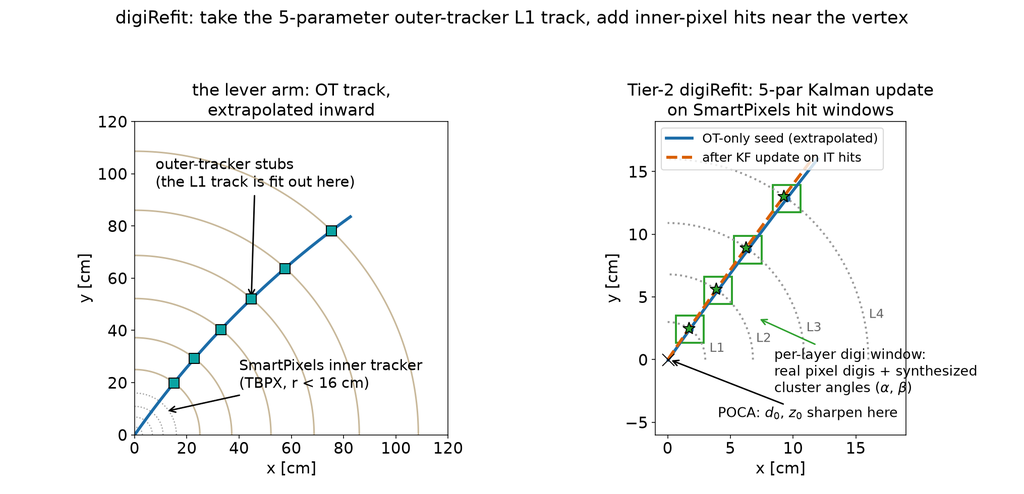

**5-par OT-only seed vs 5-par OT+IT refit** (`promptHnpar=5`, real fitted d0): project the TTTrack helix into TBPX, open a **per-layer window of real pixel digis**, synthesize the cluster angles (α, β), select at most one hit per layer, and apply a **Kalman update** to the 5-parameter track state at each layer.

Producer pipeline (per track): *window collection → digi truth-classification & angle synthesis → hit selection → sequential scalar KF update (numerical Jacobian) → loud-failure guards.* Same helix projector shared with the payload analyzer — single implementation, no drift.

## The centerpiece: step-by-step refit replay (interactive)

**Open in a browser tab:** `../eval_refitq/refitviz/refit_replay.html` — self-contained ~17 MB HTML, no server, no kernel.

[interactive chart not shown]

- **per-KF-step replay**: slider / play / step buttons through each layer's update
- seed (OT-only) vs refit helix, **covariance bands**, per-step parameter deltas
- **full-hit-set χ² column** — reduced χ² *including the OT stubs*, seed row → per-layer rows → refit row → truth footer
- **15 layer configs × 3 angle modes** (none / α / α+β), curated real tracks (clean genuine / wrong-hit pickup / fake)

## The sign bug: what the visualizer caught

**Act 1 — the symptom.** Long-running L3/L4 inefficiency and KF instability; χ² blow-ups; a saga of clamp "band-aids". Aggregate metrics: nothing obviously wrong.

**Act 2 — the visualizer.** First event on screen: the projected seed helix curled to the **mirror-image azimuthal side** of its own hits — the helix projector's parametrization curled *opposite* to the TTTrack rinv sign convention. Error grows as **r²/R**: ≈0 at L1, **≈2 mm at L4** → pulls up to **142σ**. Invisible at L1, fatal at L4.

**Act 3 — triple verification, one-line fix.**

1. circle-fit through the track's own OT stubs: R = 388 cm = stored 1/|rinv| — helix lands on its stubs only with **negated** curvature
2. per-layer residuals grow monotonically L1→L4 (0.23 mm → 2.3 mm); post-fix flat at ≈0.05 mm
3. matched-TP truth helix confirms the stored curvature sign was right — **the formula was wrong**

Fix: `const double rInv = -h.rInv;` at projector entry. The clamps it was fighting are now inert.

> **Lesson: interactive event-level inspection catches what aggregate metrics hide.**

## Post-fix: truth-validated resolution at scale

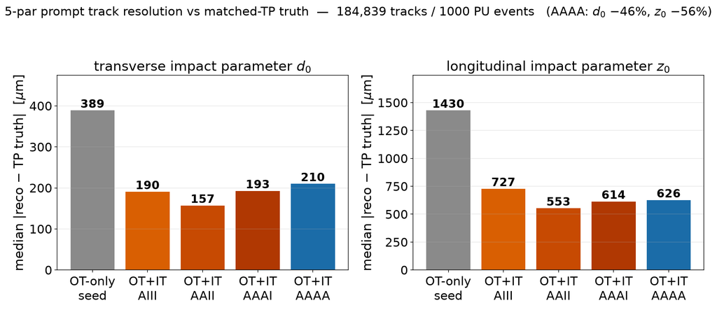

**184,839 matched tracks / 1000 PU events** (10-file post-fix production, matched-TP truth): **d0 389 → 210 µm (−46%)**, **z0 1430 → 626 µm (−56%)** for the all-layer config. The 5-par prompt seed (`promptHnpar=5`) is validated at production scale.

Note the fine print the medians reveal: **AAII (L1+L2 only) beats AAAA on the median** — outer IT layers add wrong-hit pickup (multiple scattering widens the window) alongside their constraint. Real, understood, and part of the limitations slide.

# New capabilities on top of the refit

## quality BDT → coherent tagger matrix → vertex R&D

## Refit-quality BDT (“tkquality”)

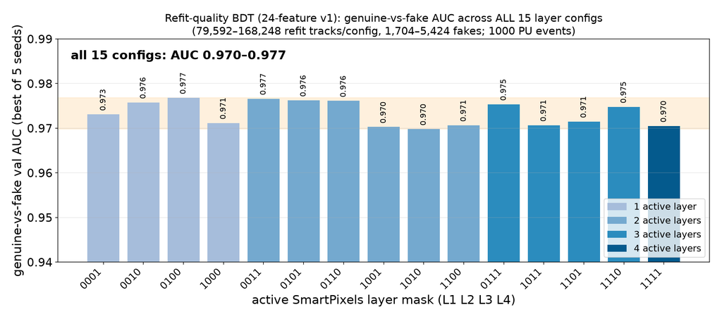

- **24-feature v1** spec (per-layer pulls, χ² increments, window occupancy, seed deltas, OT fit words)
- genuine-vs-fake **AUC 0.970–0.977 across ALL 15 layer configs** — robust to which layers are instrumented
- **conifer ↔ xgboost bit-parity**: offline float32 tree-walk matches the in-producer `conifer::BDT` (margin self-check exactly 0.0; producer parity 16410/16455 bit-exact, residuals = float32 snapshot threshold-edge cases)

## Does it help the jet tagger?

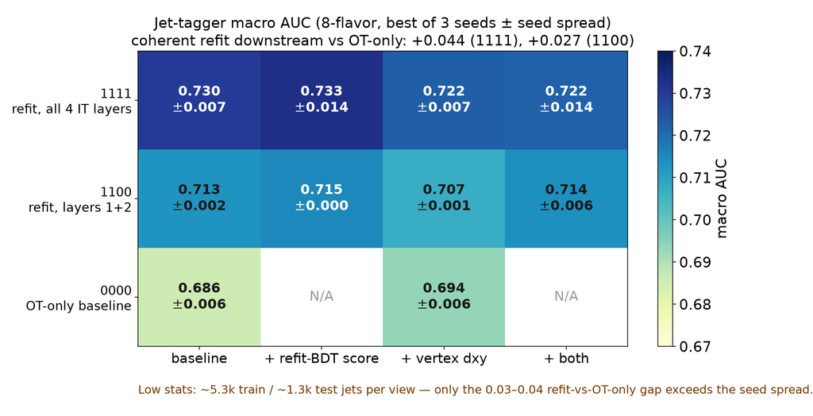

**Headline: refit-driven *coherent* downstream reco lifts the 8-flavor jet-tagger macro AUC by +0.044 (1111) / +0.027 (1100) over the OT-only baseline (0.686 → 0.730 / 0.713)** — well outside the seed spread (±0.002–0.014).

**Caveat, same breath:** ~1300 test jets per view — *only* the 0.03–0.04 refit-vs-OT-only gap is robust; every within-view feature delta is at or below seed noise.

## The feature-level story is coherent too

Each feature behaves exactly as the physics says it should — that self-consistency is the evidence the machinery is measuring something real (at these stats).

## Second interactive: the MVA explorer

**Serve it** (binary model files — `file://` will not fetch them):

```
cd ngtagger-train && python3 -m http.server 8000
```

then open [`http://localhost:8000/eval_mva_explorer/site/explorer.html`](http://localhost:8000/eval_mva_explorer/site/explorer.html)

[interactive chart not shown]

- panels for **regressions / tkquality / tagger**; overlay any tuple of trainings
- working-point efficiency curves, per-bin AUC, score distributions — all client-side

## Vertex emulators (one slide)

Context: baseline GTT primary vertex is **FastHisto** (histogram tracks in z0, pick the peak); **NNVtx** is the ML alternative. Our R&D on top of the refit tracks:

- **transverse vertex (dx, dy) least-squares**: closed-form normal equations from track (d0, φ0) — a beam-spot-scale transverse fit from L1 tracks, with significance
- **kernel peak-finder**: replace FastHisto's flat window with tapered kernels (triangular / Gaussian / Epanechnikov) — in two-close-vertices toys the tapered kernel **halves the midpoint mis-pick rate**
- feeds the tagger's `vertexdxy` feature group (the one that lifted the OT-only view)

## Close: the payoff, and what's next

**Every rung already paid out**: refit machinery (truth-linked nano loop) → quality BDT (bit-exact FPGA path, robust across configs) → coherent reco (+0.04 tagger AUC at low stats) — each with Phase-2-baseline value independent of SmartPixels adoption.

**Next:**

1. **Real production statistics** — the recipe is productionized; waiting on 200-PU input procurement
2. **ASIC-fidelity payloads** — wire measured ASIC response/efficiency into the reserved hooks
3. **The TS0 lever — score transmission**: today the quality-BDT score reaches the tagger *only offline*. Making it visible to PF track selection is a **config-only** change (cut-strings can read `trkMVA1`); carrying it into the **candidate word** for the tagger is a hardware/word-format change — the concrete, costed ask for the hardware discussion.

# Backup

*dark-sector reach · truth postures · KF guards · per-flavor tables · parity details*

## Backup: dark-sector L1 sensitivity (the bonus physics)

- Signature map: soft-unclustered energy patterns (**SUEP** flagship — rebuilt after the multiplicity-based version was refuted), displaced/low-pT track signatures needing IT-level info at L1
- **One placement, two capabilities**: a proposed subsystem between {L1TrackFinder + SmartPixels track finder} and {GTT / GMT / correlator} — graph-track **condensation** + **reseeding**
- **Upstream-payoff thesis**: the observables and the condensation/reseeding subsystem are contributions to the *baseline Phase-2 track trigger*, decoupled from SmartPixels adoption risk — speculative R&D de-risked by its spinoffs

## Backup: truth postures (why three)

Association maps are Ref-keyed — mixing collections silently breaks truth. Hence:

- **Posture B `inJob`** (default): remake digis→stubs→tracks→maps self-consistently — all noPU development
- **Posture A `fromFile`**: file tracks + file maps + file digis — needed when re-digitizing would lose PU; but old-layout file tracks have all-zero helix covariance → forces parametrized seeding
- **Posture C `fromFileStubs`** (production): rebuild tracks from the file's persisted **stub** tier → real PU **and** genuine seed covariance (`seedCovMode="trackCov"` valid on PU files)

## Backup: KF guards — post-fix status

| guard | default | post-fix firing | verdict |
| --- | --- | --- | --- |
| `jacobianMaxAbs` | 10⁴ | **0** | inert (was a bug band-aid); can drop |
| `chi2UpdateGate` | 2×10⁶ | **0** | keep as cheap numerical backstop |
| `predAngleMaxAbs` | 12 | ~5 / 100 evt | cosmetic; relax freely |
| `measAngleMaxAbs` | 12 | 0.12% of accepted-hit angles | **relax 12 → ~30–50**, keep as guard |

## Backup: stage-4 per-flavor AUC (best seed)

| view / features | b | charm | light | gluon | τ⁺ | τ⁻ | μ | e |
| --- | --- | --- | --- | --- | --- | --- | --- | --- |
| 1111 baseline | 0.706 | 0.569 | 0.590 | 0.748 | 0.706 | 0.727 | 0.911 | 0.879 |
| 1111 +refitBDT | 0.707 | 0.572 | 0.597 | 0.748 | **0.733** | 0.720 | 0.905 | 0.881 |
| 1100 baseline | 0.711 | 0.571 | 0.594 | 0.776 | 0.711 | 0.540 | 0.915 | 0.886 |
| 0000 baseline | 0.675 | 0.600 | 0.572 | 0.756 | 0.534 | 0.564 | 0.886 | 0.901 |
| 0000 +vtxDxy | 0.675 | 0.589 | 0.571 | 0.753 | 0.526 | **0.645** | 0.897 | 0.893 |

8-class one-vs-rest; ~1300 test jets/view; full 11-cell matrix in `eval_refitq/stage4/stage4_summary.json`.

## Backup: refit-BDT deployment path (parity receipts)

- Export: `train-refitquality --export-conifer` → conifer JSON + metadata (feature order, spec version, margin semantics, provenance)
- Margin semantics: conifer/producer compute the **raw booster logit margin**; the sklearn `predict(output_margin=True)` wrapper disagrees by up to 0.86 on xgboost≥2 — always reference the booster
- Producer parity: 16410/16455 trkMVA1 **bit-exact** vs the float32 offline walk; the 45 residuals are float32-snapshot values crossing strict-`<` split thresholds (one-leaf steps)
- Stage-3 v1 models: `conifer_margin_selfcheck = 0.0` on all 15 configs
- The score lands in `trkMVA1` on the refit track word — the hook the TS0 lever builds on